# Landsat NDVI Seasonality Analysis

Gianfranco Villamonte Cuneo

2026-06-01

# 1 Overview

This document compiles a vegetation-index seasonality workflow originally developed for repeated environmental monitoring tasks. The workflow combines Google Earth Engine and R to extract, clean, visualize and decompose a Landsat-derived NDVI time series.

The purpose of this analysis is to identify intra-annual vegetation seasonality and check whether there is a visible interannual NDVI trend. The workflow is based on public Landsat data and is presented here as a reproducible remote-sensing and ecological monitoring example.

The workflow includes:

- extraction of NDVI, NDWI and image-quality information in Google Earth Engine;
- preparation of a monthly NDVI table exported from Google Earth Engine;
- exploratory boxplots by month, quarter and year;
- non-parametric tests for seasonal and interannual differences;
- missing-value imputation with a Kalman filter;
- seasonal-trend decomposition using Loess (STL);
- visualization of known and imputed values, seasonal patterns and long-term trend components.

# 2 Google Earth Engine extraction

The NDVI table used in this example was obtained from public Landsat imagery through Google Earth Engine. The original workflow was repeated across different projects by changing the area of interest, time window and index selection.

The portfolio version uses a neutralized extraction template. Replace the area-of-interest coordinates and dates before running it in Google Earth Engine.

```javascript
// Landsat vegetation-index time-series extraction template for Google Earth Engine
// Replace the AOI coordinates and dates before running.

// 1. Define the area of interest (longitude/latitude in decimal degrees).
var aoi = ee.Geometry.Rectangle([lon_min, lat_min, lon_max, lat_max]);

// 2. Load Landsat 8 composite collections for vegetation and quality assessment.
// This template follows the legacy workflow used for the original analysis.
var ndviCollection = ee.ImageCollection('LANDSAT/LC08/C01/T1_8DAY_NDVI')
  .filterDate('2013-02-01', '2021-08-31')
  .select('NDVI');

var ndwiCollection = ee.ImageCollection('LANDSAT/LC08/C01/T1_8DAY_NDWI')
  .filterDate('2013-02-01', '2021-08-31')
  .select('NDWI');

var bqaCollection = ee.ImageCollection('LANDSAT/LC08/C01/T1_8DAY_TOA')
  .filterDate('2013-02-01', '2021-08-31')
  .select('BQA');

// 3. Chart mean values within the AOI.
var ndviOptions = {
  lineWidth: 1,
  title: 'NDVI variation',
  vAxis: {title: 'NDVI'},
  legend: {position: 'none'},
  hAxis: {title: 'Date'}
};

var ndwiOptions = {
  lineWidth: 1,
  title: 'NDWI variation',
  vAxis: {title: 'NDWI'},
  legend: {position: 'none'},
  hAxis: {title: 'Date'}
};

var bqaOptions = {
  lineWidth: 1,
  title: 'BQA variation',
  vAxis: {title: 'BQA'},
  legend: {position: 'none'},
  hAxis: {title: 'Date'}
};

print(Chart.image.series(ndviCollection, aoi, ee.Reducer.mean(), 30).setOptions(ndviOptions));
print(Chart.image.series(ndwiCollection, aoi, ee.Reducer.mean(), 30).setOptions(ndwiOptions));
print(Chart.image.series(bqaCollection, aoi, ee.Reducer.mean(), 30).setOptions(bqaOptions));

// 4. Visualize the AOI.
Map.addLayer(aoi, {}, 'Area of interest');
Map.centerObject(aoi, 10);
```

In the original workflow, image-quality information was reviewed to remove cloud-affected observations before calculating monthly NDVI values. The cleaned monthly NDVI table is the input used in the R sections below.

# 3 R setup

```r
packages <- c(
  "readxl", "dplyr", "tidyr", "ggplot2", "viridis", "imputeTS",
  "forecast", "lubridate", "scales", "knitr"
)

# Set a CRAN mirror before installing missing packages. This prevents knitting
# errors in fresh R sessions where no default repository has been configured.
options(repos = c(CRAN = "https://cloud.r-project.org"))

missing_packages <- packages[!vapply(packages, requireNamespace, logical(1), quietly = TRUE)]
if (length(missing_packages) > 0) {
  install.packages(missing_packages, dependencies = TRUE)
}

invisible(lapply(packages, library, character.only = TRUE))

theme_set(theme_bw())
```

# 4 Data import

The example file was renamed to avoid project-specific naming:

```r
data_file <- "landsat_ndvi_timeseries_example.xlsx"
data_sheet <- "T2.4.1.1(Estacionalidad)"
```

The workbook contains a formatted table with title rows above the actual headers, so the import skips the first three rows.

```r
raw_ndvi <- read_excel(
  path = data_file,
  sheet = data_sheet,
  skip = 3
)

names(raw_ndvi) <- tolower(names(raw_ndvi))
names(raw_ndvi) <- gsub("año", "anio", names(raw_ndvi), fixed = TRUE)
names(raw_ndvi) <- gsub("í", "i", names(raw_ndvi), fixed = TRUE)
names(raw_ndvi) <- gsub(" ", "_", names(raw_ndvi), fixed = TRUE)

raw_ndvi <- raw_ndvi %>%
  rename(
    fecha = fecha,
    mes = mes,
    anio = anio,
    trim = trimestre,
    ndvi = ndvi
  )

head(raw_ndvi)
```

```
## # A tibble: 6 × 5
##   fecha                 mes  anio  trim  ndvi
##   <dttm>              <dbl> <dbl> <dbl> <dbl>
## 1 2013-05-25 00:00:00     5  2013     2 0.218
## 2 2013-06-10 00:00:00     6  2013     2 0.195
## 3 2013-07-28 00:00:00     7  2013     3 0.183
## 4 2013-08-13 00:00:00     8  2013     3 0.178
## 5 2013-09-14 00:00:00     9  2013     3 0.172
## 6 2013-10-16 00:00:00    10  2013     4 0.172
```

# 5 Data preparation

Dates exported from Excel are usually stored as serial numbers. The following code converts them into R dates and builds a complete monthly time series.

```r
excel_serial_to_date <- function(x) {
  if (inherits(x, "Date")) return(x)
  if (inherits(x, "POSIXct") || inherits(x, "POSIXt")) return(as.Date(x))
  if (is.numeric(x)) return(as.Date(x, origin = "1899-12-30"))
  as.Date(x)
}

ndvi_data <- raw_ndvi %>%
  mutate(
    fecha = excel_serial_to_date(fecha),
    mes = as.integer(mes),
    anio = as.integer(anio),
    trim = as.integer(trim),
    ndvi = as.numeric(ndvi),
    month_date = as.Date(sprintf("%04d-%02d-01", anio, mes))
  ) %>%
  filter(!is.na(month_date)) %>%
  arrange(month_date)

# If the exported data contains more than one valid observation per month,
# aggregate to a monthly mean. Missing months are retained as NA.
monthly_ndvi <- ndvi_data %>%
  group_by(month_date) %>%
  summarise(
    anio = first(anio),
    mes = first(mes),
    trim = first(trim),
    ndvi = mean(ndvi, na.rm = TRUE),
    n_valid = sum(!is.na(ndvi)),
    .groups = "drop"
  ) %>%
  mutate(ndvi = ifelse(is.nan(ndvi), NA_real_, ndvi)) %>%
  complete(
    month_date = seq(min(month_date), max(month_date), by = "month")
  ) %>%
  mutate(
    anio = ifelse(is.na(anio), lubridate::year(month_date), anio),
    mes = ifelse(is.na(mes), lubridate::month(month_date), mes),
    trim = ifelse(is.na(trim), lubridate::quarter(month_date), trim),
    anio = as.integer(anio),
    mes = as.integer(mes),
    trim = as.integer(trim)
  ) %>%
  arrange(month_date)

summary(monthly_ndvi$ndvi)
```

```
##    Min. 1st Qu.  Median    Mean 3rd Qu.    Max.    NA's
##  0.1530  0.1834  0.1990  0.2180  0.2391  0.3340      32
```

```r
knitr::kable(head(monthly_ndvi, 12), caption = "First year of the monthly NDVI table used in the analysis.")
```

First year of the monthly NDVI table used in the analysis.

| month_date | anio | mes | trim | ndvi | n_valid |
| --- | --- | --- | --- | --- | --- |
| 2013-05-01 | 2013 | 5 | 2 | 0.2180 | 1 |
| 2013-06-01 | 2013 | 6 | 2 | 0.1950 | 1 |
| 2013-07-01 | 2013 | 7 | 3 | 0.1830 | 1 |
| 2013-08-01 | 2013 | 8 | 3 | 0.1780 | 1 |
| 2013-09-01 | 2013 | 9 | 3 | 0.1715 | 1 |
| 2013-10-01 | 2013 | 10 | 4 | 0.1720 | 1 |
| 2013-11-01 | 2013 | 11 | 4 | 0.1770 | 1 |
| 2013-12-01 | 2013 | 12 | 4 | 0.2000 | 1 |
| 2014-01-01 | 2014 | 1 | 1 | NA | 0 |
| 2014-02-01 | 2014 | 2 | 1 | 0.2390 | 1 |
| 2014-03-01 | 2014 | 3 | 1 | 0.2880 | 1 |
| 2014-04-01 | 2014 | 4 | 2 | 0.2815 | 1 |

# 6 Exploratory seasonal checks

The first diagnostic step is to assess whether NDVI values differ across months or quarters. Because NDVI values are not expected to be normally distributed in this type of monthly ecological time series, non-parametric Kruskal-Wallis tests are used after checking normality.

```r
observed_ndvi <- monthly_ndvi %>% filter(!is.na(ndvi))

normality_test <- shapiro.test(observed_ndvi$ndvi)
kw_month <- kruskal.test(ndvi ~ factor(mes), data = observed_ndvi)
kw_quarter <- kruskal.test(ndvi ~ factor(trim), data = observed_ndvi)
kw_year <- kruskal.test(ndvi ~ factor(anio), data = observed_ndvi)

list(
  shapiro_wilk = normality_test,
  kruskal_month = kw_month,
  kruskal_quarter = kw_quarter,
  kruskal_year = kw_year
)
```

```
## $shapiro_wilk
##
##  Shapiro-Wilk normality test
##
## data:  observed_ndvi$ndvi
## W = 0.87632, p-value = 6.63e-06
##
##
## $kruskal_month
##
##  Kruskal-Wallis rank sum test
##
## data:  ndvi by factor(mes)
## Kruskal-Wallis chi-squared = 57.951, df = 11, p-value = 2.222e-08
##
##
## $kruskal_quarter
##
##  Kruskal-Wallis rank sum test
##
## data:  ndvi by factor(trim)
## Kruskal-Wallis chi-squared = 46.84, df = 3, p-value = 3.758e-10
##
##
## $kruskal_year
##
##  Kruskal-Wallis rank sum test
##
## data:  ndvi by factor(anio)
## Kruskal-Wallis chi-squared = 13.844, df = 8, p-value = 0.08592
```

## 6.1 NDVI by month

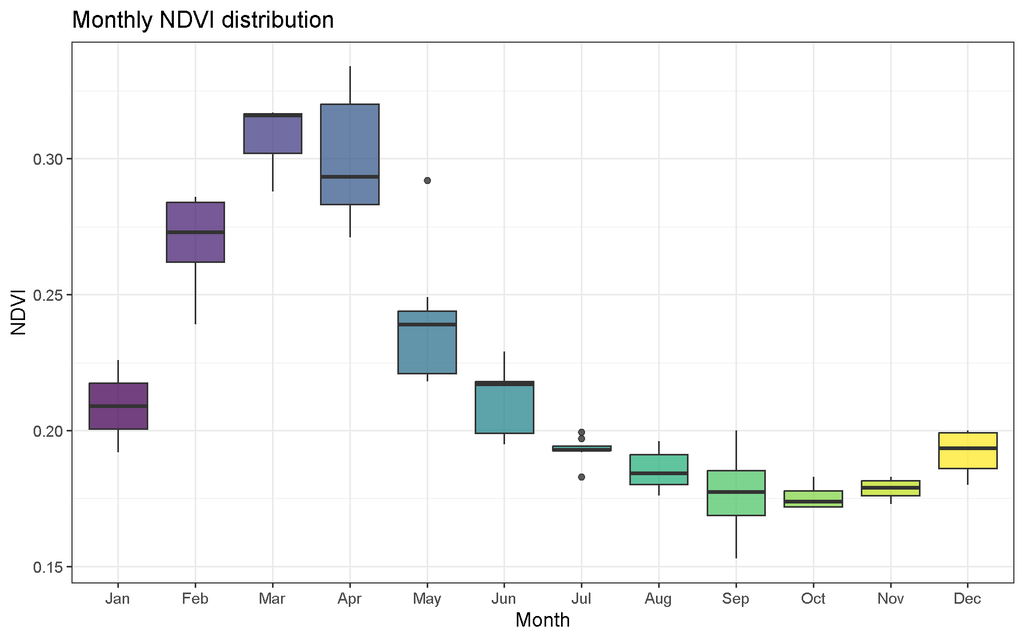

```r
observed_ndvi %>%
  mutate(month_label = factor(month.abb[mes], levels = month.abb)) %>%
  ggplot(aes(x = month_label, y = ndvi, fill = month_label)) +
  geom_boxplot(alpha = 0.75, outlier.alpha = 0.8) +
  scale_fill_viridis_d(option = "D") +
  labs(
    x = "Month",
    y = "NDVI",
    fill = "Month",
    title = "Monthly NDVI distribution"
  ) +
  theme(legend.position = "none")
```

## 6.2 NDVI by quarter

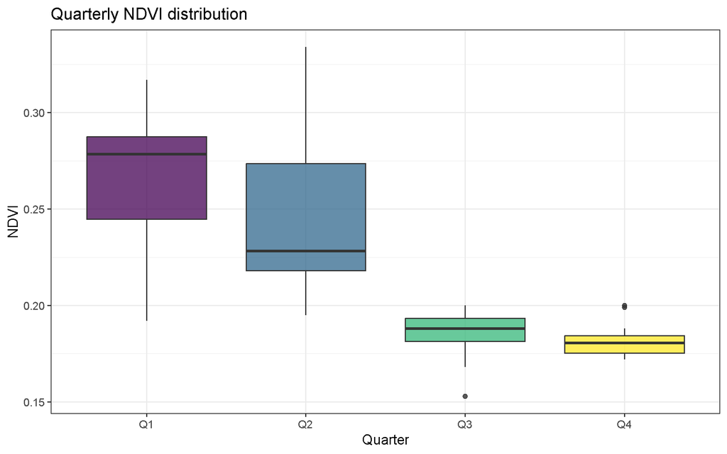

```r
observed_ndvi %>%
  mutate(quarter_label = factor(paste0("Q", trim), levels = paste0("Q", 1:4))) %>%
  ggplot(aes(x = quarter_label, y = ndvi, fill = quarter_label)) +
  geom_boxplot(alpha = 0.75, outlier.alpha = 0.8) +
  scale_fill_viridis_d(option = "D") +
  labs(
    x = "Quarter",
    y = "NDVI",
    fill = "Quarter",
    title = "Quarterly NDVI distribution"
  ) +
  theme(legend.position = "none")
```

## 6.3 NDVI by year

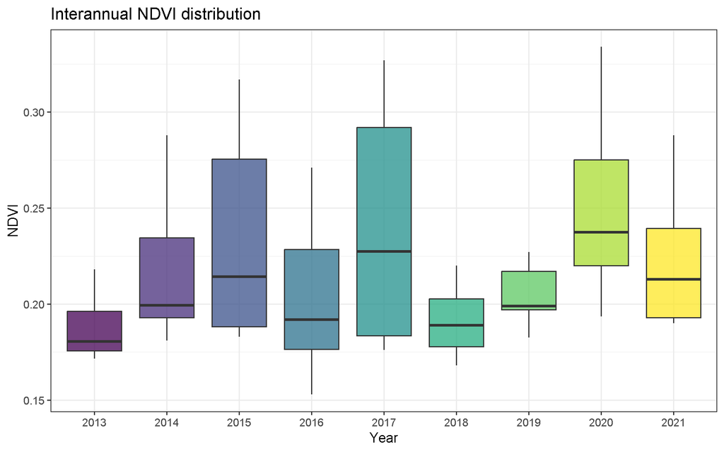

```r
observed_ndvi %>%
  mutate(year_label = factor(anio)) %>%
  ggplot(aes(x = year_label, y = ndvi, fill = year_label)) +
  geom_boxplot(alpha = 0.75, outlier.alpha = 0.8) +
  scale_fill_viridis_d(option = "D") +
  labs(
    x = "Year",
    y = "NDVI",
    fill = "Year",
    title = "Interannual NDVI distribution"
  ) +
  theme(legend.position = "none")
```

# 7 Monthly time series

```r
start_year <- lubridate::year(min(monthly_ndvi$month_date))
start_month <- lubridate::month(min(monthly_ndvi$month_date))
end_year <- lubridate::year(max(monthly_ndvi$month_date))
end_month <- lubridate::month(max(monthly_ndvi$month_date))

ndvi_ts <- ts(
  monthly_ndvi$ndvi,
  start = c(start_year, start_month),
  end = c(end_year, end_month),
  frequency = 12
)

ndvi_ts
```

```
##         Jan    Feb    Mar    Apr    May    Jun    Jul    Aug    Sep    Oct
## 2013                             0.2180 0.1950 0.1830 0.1780 0.1715 0.1720
## 2014     NA 0.2390 0.2880 0.2815 0.2210 0.1990 0.1920 0.1960 0.2000     NA
## 2015     NA 0.2860 0.3170 0.2990 0.2440 0.2290 0.1995 0.1950 0.1860 0.1830
## 2016 0.1920 0.2620     NA 0.2710 0.2390 0.2180 0.1930 0.1860 0.1530 0.1720
## 2017     NA 0.2730 0.3160 0.3270 0.2920 0.2275 0.1930 0.1760 0.1835 0.1760
## 2018     NA     NA     NA     NA 0.2200 0.1970     NA 0.1810 0.1680     NA
## 2019     NA     NA     NA     NA 0.2270 0.2170 0.1970 0.1825     NA     NA
## 2020 0.2260 0.2840     NA 0.3340 0.2490 0.2180 0.1935     NA     NA     NA
## 2021     NA     NA     NA 0.2880 0.2395 0.2130 0.1930 0.1900
##         Nov    Dec
## 2013 0.1770 0.2000
## 2014 0.1810 0.1880
## 2015 0.1830     NA
## 2016 0.1730 0.1800
## 2017     NA     NA
## 2018     NA     NA
## 2019     NA 0.1990
## 2020     NA     NA
## 2021
```

```r
missing_summary <- as.data.frame(statsNA(ndvi_ts, bins = 4, print_only = FALSE))
knitr::kable(head(missing_summary, 8), caption = "Missing-value summary for the monthly NDVI time series.")
```

Missing-value summary for the monthly NDVI time series.

| length_series | number_NAs | number_na_gaps | average_size_na_gaps | percentage_NAs | longest_na_gap | most_frequent_na_gap | most_weighty_na_gap | df_distribution_na_gaps |
| --- | --- | --- | --- | --- | --- | --- | --- | --- |
| 100 | 32 | 12 | 2.666667 | 32% | 8 | 1 | 8 | 8 |
| 100 | 32 | 12 | 2.666667 | 32% | 8 | 1 | 8 | 0 |
| 100 | 32 | 12 | 2.666667 | 32% | 8 | 1 | 8 | 1 |
| 100 | 32 | 12 | 2.666667 | 32% | 8 | 1 | 8 | 0 |
| 100 | 32 | 12 | 2.666667 | 32% | 8 | 1 | 8 | 0 |
| 100 | 32 | 12 | 2.666667 | 32% | 8 | 1 | 8 | 1 |
| 100 | 32 | 12 | 2.666667 | 32% | 8 | 1 | 8 | 1 |
| 100 | 32 | 12 | 2.666667 | 32% | 8 | 1 | 8 | 1 |

# 8 Kalman imputation

Cloud filtering and satellite acquisition gaps can leave missing observations. The original workflow used Kalman filtering through `imputeTS::na_kalman()` to complete the monthly time series before decomposition.

```r
ndvi_imputed <- na_kalman(
  ndvi_ts,
  model = "StructTS",
  smooth = TRUE
)

monthly_ndvi <- monthly_ndvi %>%
  mutate(
    ndvi_imputed = as.numeric(ndvi_imputed),
    value_type = ifelse(is.na(ndvi), "Imputed", "Observed")
  )
```

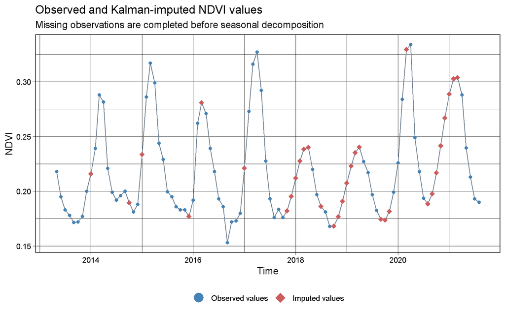

```r
ggplot_na_imputations(
  x_with_na = ndvi_ts,
  x_with_imputations = ndvi_imputed,
  x_axis_labels = monthly_ndvi$month_date,
  title = "Observed and Kalman-imputed NDVI values",
  subtitle = "Missing observations are completed before seasonal decomposition",
  xlab = "Time",
  ylab = "NDVI",
  label_known = "Observed values",
  label_imputations = "Imputed values",
  theme = ggplot2::theme_linedraw()
)
```

## 8.1 Optional imputation validation

The true value of a missing observation is unknown, so imputation accuracy cannot be measured directly for genuinely missing dates. As a basic validation check, the code below masks a subset of observed values, imputes them, and compares the imputed values against the withheld observations.

```r
set.seed(123)
observed_index <- which(!is.na(ndvi_ts))
validation_size <- max(1, floor(length(observed_index) * 0.2))
validation_index <- sample(observed_index, validation_size)

ndvi_masked <- ndvi_ts
ndvi_masked[validation_index] <- NA

ndvi_validation_imputed <- na_kalman(
  ndvi_masked,
  model = "StructTS",
  smooth = TRUE
)

actual_values <- as.numeric(ndvi_ts[validation_index])
predicted_values <- as.numeric(ndvi_validation_imputed[validation_index])

mape <- mean(abs((actual_values - predicted_values) / actual_values), na.rm = TRUE) * 100
mae <- mean(abs(actual_values - predicted_values), na.rm = TRUE)
rmse <- sqrt(mean((actual_values - predicted_values)^2, na.rm = TRUE))

validation_metrics <- tibble::tibble(
  metric = c("MAE", "RMSE", "MAPE (%)"),
  value = c(mae, rmse, mape)
)

knitr::kable(validation_metrics, digits = 4, caption = "Validation metrics from artificially withheld observed NDVI values.")
```

Validation metrics from artificially withheld observed NDVI values.

| metric | value |
| --- | --- |
| MAE | 0.0269 |
| RMSE | 0.0429 |
| MAPE (%) | 13.8984 |

# 9 STL decomposition

Seasonal and Trend decomposition using Loess (STL) separates the completed time series into:

- a seasonal component, representing recurring intra-annual variation;
- a trend component, representing longer-term change;
- a remainder component, representing residual variation.

```r
ndvi_stl <- stl(ndvi_imputed, s.window = 12)

stl_components <- as.data.frame(ndvi_stl$time.series) %>%
  mutate(
    month_date = monthly_ndvi$month_date,
    anio = monthly_ndvi$anio,
    mes = monthly_ndvi$mes
  )

head(stl_components)
```

```
##       seasonal     trend    remainder month_date anio mes
## 1  0.022247019 0.2031479 -0.007394882 2013-05-01 2013   5
## 2 -0.004205644 0.2042254 -0.005019737 2013-06-01 2013   6
## 3 -0.024496422 0.2053029  0.002193523 2013-07-01 2013   7
## 4 -0.030853673 0.2063804  0.002473256 2013-08-01 2013   8
## 5 -0.038094976 0.2074218  0.002173206 2013-09-01 2013   9
## 6 -0.038148743 0.2084631  0.001685622 2013-10-01 2013  10
```

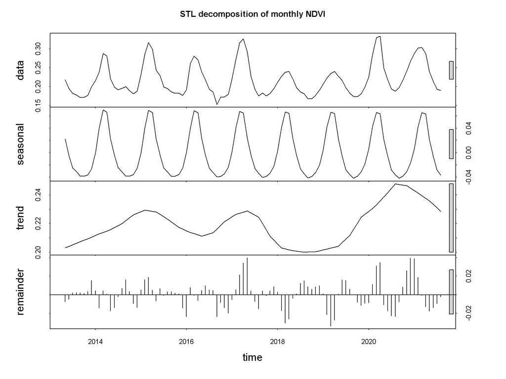

```r
plot(ndvi_stl, main = "STL decomposition of monthly NDVI")
```

## 9.1 Seasonal pattern

The seasonal component shows the typical monthly deviation from the long-term NDVI signal. Positive values indicate months where vegetation vigor is above the average seasonal baseline, while negative values indicate months below that baseline.

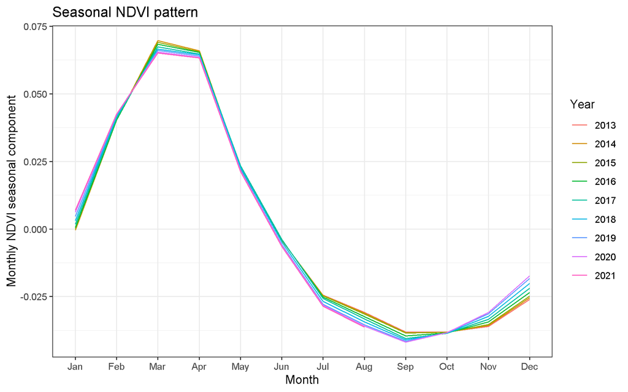

```r
seasonal_ts <- ts(
  stl_components$seasonal,
  start = c(start_year, start_month),
  frequency = 12
)

forecast::ggseasonplot(seasonal_ts, year.labels = FALSE) +
  labs(
    x = "Month",
    y = "Monthly NDVI seasonal component",
    color = "Year",
    title = "Seasonal NDVI pattern"
  ) +
  theme_bw() +
  theme(legend.position = "right")
```

## 9.2 Interannual trend

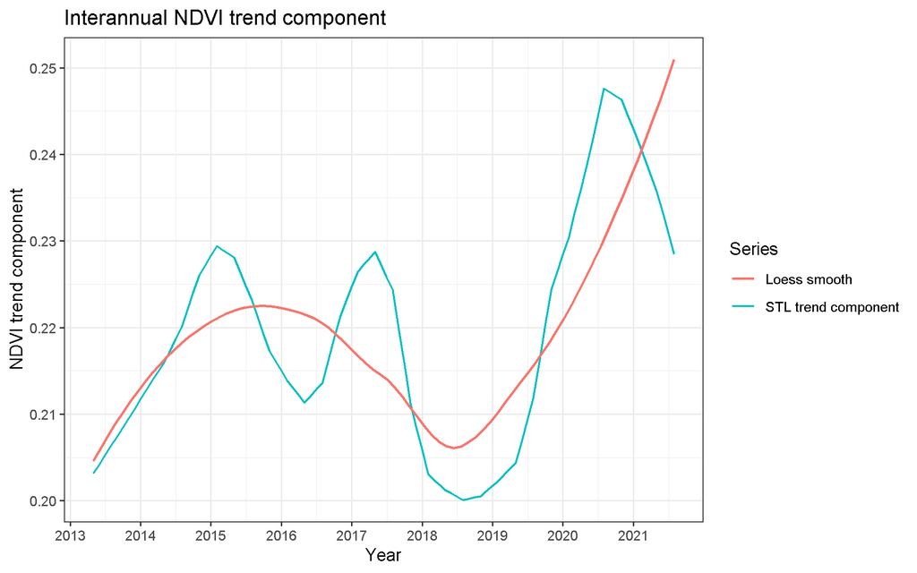

```r
ggplot(stl_components, aes(x = month_date, y = trend)) +
  geom_line(aes(color = "STL trend component"), linewidth = 0.7) +
  geom_smooth(aes(color = "Loess smooth"), se = FALSE, linewidth = 0.8) +
  scale_x_date(date_breaks = "1 year", date_labels = "%Y") +
  labs(
    x = "Year",
    y = "NDVI trend component",
    color = "Series",
    title = "Interannual NDVI trend component"
  ) +
  theme(legend.position = "right")
```

# 10 Interpretation guide

Use the outputs as follows:

- A significant Kruskal-Wallis test by month or quarter supports the presence of seasonal NDVI variation.
- A non-significant Kruskal-Wallis test by year suggests no strong interannual shift in the distribution of NDVI values over the period analysed.
- The Kalman-imputed time series is used to support continuous decomposition, not to replace field-based ecological interpretation.
- The STL seasonal component helps identify months where vegetation vigor is consistently above or below the long-term average.
- The trend component should be interpreted cautiously because NDVI can respond to climate variability, vegetation phenology, land-cover change, image quality and sensor-processing effects.

# 11 Notes on public use

This example is based on public Landsat-derived vegetation-index data. Project-specific names and assets were removed from the compiled workflow. The repository should be read as a methodological example of vegetation seasonality analysis, not as a formal assessment of any specific site, company or mining operation.